# Effects of user age, user gender, user type and days of week on trip duration

## by Pacifique Clement Ndayisenga

## Investigation Overview

In my investigation, I was interested in how trip duration is dependent on other features such as age, user type, user gender, and day of the week. My focus was on age, user type, gender and days of the week and what is their impact on the trip duration.

## Dataset Overview

The dataset includes information about individual rides made in a bike-sharing system covering the greater San Francisco Bay area. The dataset consists of 183412 rides taken in a bike-sharing system covering the greater San Francisco Bay area in the month of February of 2019. The dataset consists of 16 features that include trip duration in seconds, rider type and gender, the start and end timestamp of the trip and so on.

## Trip duration distribution

Trip durations in the dataset take on a very large range of values, but the average trip duration is around 500 seconds.

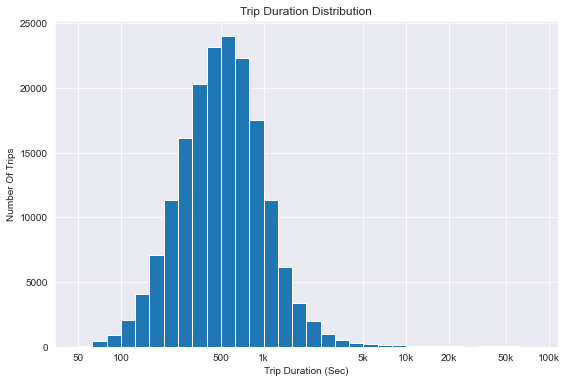

## Trip duration vs Age

Young riders spend more time in a trip than the older ones. Most of them are between 20 and 50 years old.

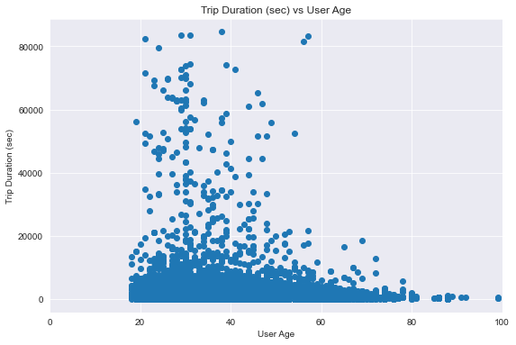

## Trip duration vs Day

Weekend trips take longer compared to the ones taken during the week

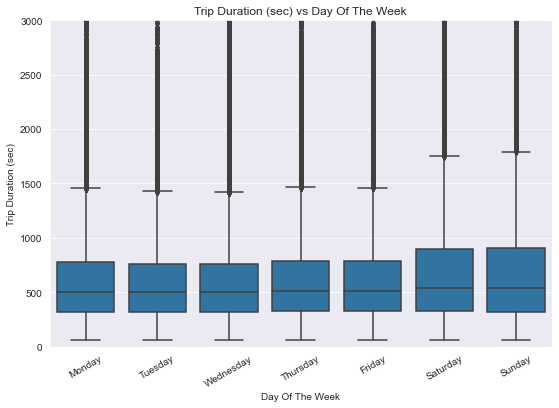

## Trip duration vs User type

Customer users spend more time in a trip than subscribed users

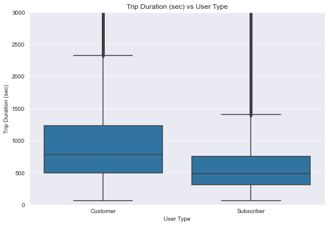

## Trip duration vs User gender

Female and other genders spend more time in a trip than male users

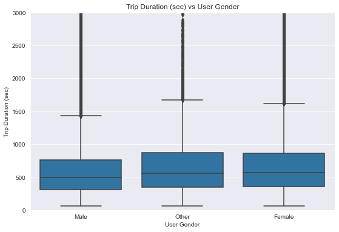